# The Effect of Education on Income

Samuel Queen

16 June, 2025

## Introduction

This project serves as my reintroduction to econometric techniques, using statistical methods, and is my first foray into the R language. I have been teaching myself R and started using it more at work and felt like now was the time to take on my first research project. We start with a simple question, does having more education lead to higher earnings? There are what seem to be entire libraries dedicated to this research topic, so I will not pretend to say I have uncovered some groundbreaking revelations or anything like that. In fact we already know the answer, and it is a resounding yes. What I am attempting to do is see if this relationship is present within Census SIPP (survey of income and program participation) survey data and if I can accurately model/capture the expected increase in income. This will be a cross sectional analysis using a multiple OLS general survey regression model.

To learn more about SIPP data click here:  
[SIPP Overview](https://www.census.gov/programs-surveys/sipp.html)  
[About SIPP](https://www.census.gov/programs-surveys/sipp/about.html)  
[SIPP Methodology](https://www.census.gov/programs-surveys/sipp/methodology.html)

To learn more about the assumptions for OLS regressions, click here:  
[Linear Regression Overview](https://en.wikipedia.org/wiki/Linear_regression)

## Exploratory Data Analysis

Before we dive into our main insights and investigation through linear regression, we must first explore the covariation between our main explanatory variables (education levels, age, race, and gender) to visually confirm that there are observable trends between them and monthly income. This will also help us to confirm the trends that are common knowledge as well. The basic insights gleaned here should provide evidence that I am correct in using these variables to capture the effects of education on income. Lastly, I am going to show that the variables described in the Mincer Equation for human capital earnings are a good basis for this statistical model.

Let’s first start by visualizing the relationship between educational attainment and reported monthly income. Notice there are two charts, the first visualizes the relationship between high school diploma attainment and monthly income, while the second plot shows a more detailed breakdown of education by secondary and post secondary educational attainment.

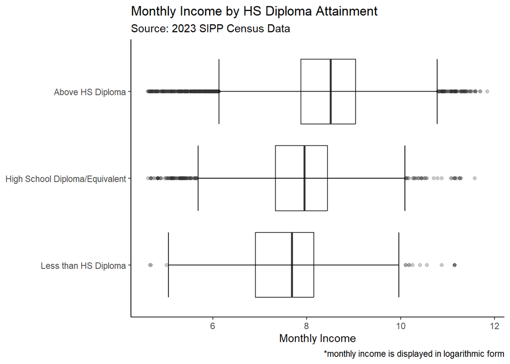

As we expect, there is a noticeable trend that shows that earning a high school diploma typically results in a higher reported monthly income. However, there are a noticeable amount of outlier observations that do not fit within the minimum or maximum (the 0th percentile or the 100th percentile) using the standard 1.5 IQR distance from the upper quartile (Q3) and the lower quartile (Q1). These outliers are mainly located in the “Above HS Diploma” category. This is reasonable to see as that category is a combination of more detailed educational outcomes. For example, a respondent with an Associate’s degree and another respondent with a Master’s degree are both labeled as “Above HS Diploma” in this plot. Higher degrees of variation make sense using these descriptors. I expect to see a lower amount of outliers if I expand the educational attainment variables to a more detailed level. Lets see what that plot looks like.

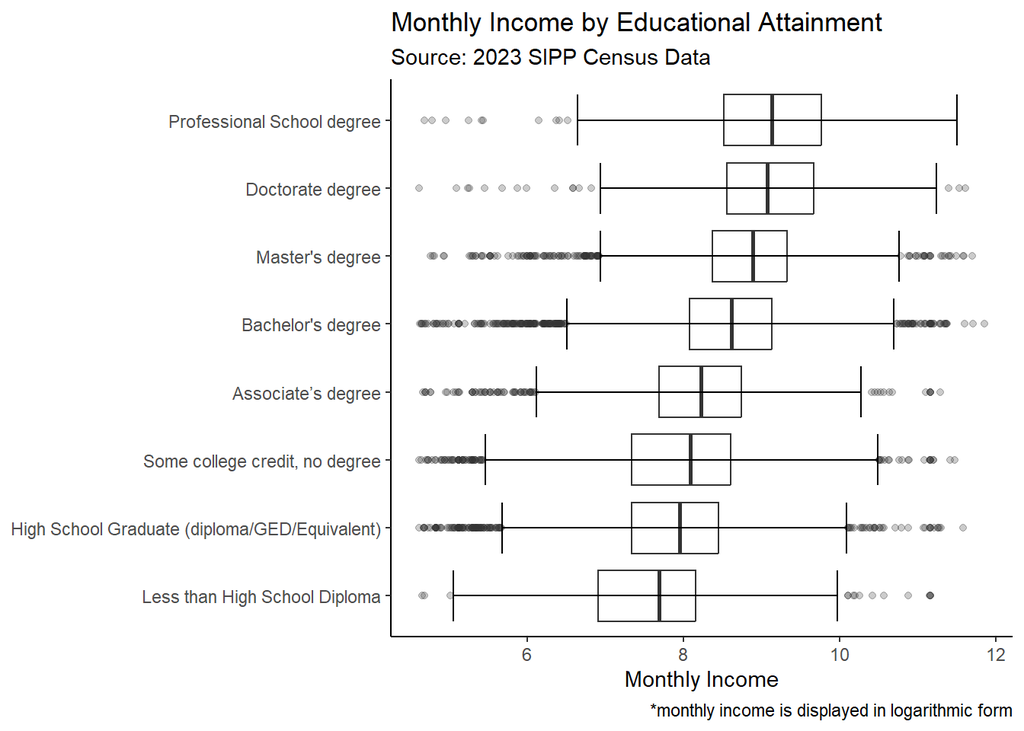

As expected, we see a similar trend, higher education showing a higher median monthly income amount. We also get a better sense of where our outliers live, specifically which educational attainment category. By my eye, the categories for Bachelor’s and Master’s degree have the highest frequency of outliers compared to the other categories. Regardless, the generally positive trend we see for educational attainment helps us to confirm that we are investigating in the right area and are honing in on a solid foundation for our linear regression.

Now that we have visualized the basic relationship between our main variable of interest (educational attainment) and our dependent variable (income) we must also consider other covariates that are necessary for accurate modeling and in-depth analysis. Enter the Mincer Equation. The Mincer Earnings Function is a single equation model that describes wage income as a function of schooling and experience. The Mincer equation is one of the most widely references models in econometrics and still has practical applications today.

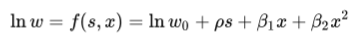

Formal Model

One of the key attributes of this specific model is the quadratic function that captures “years of potential experience”. For this analysis, I determined that age of the respondent (specifically at the time of the interview) can act as a substitute for work experience. I would have liked to include some type of “time spent at job” or “seniority level” variable to directly reflect this but I could not find a question that specific. However, visually speaking the age variable will suffice.

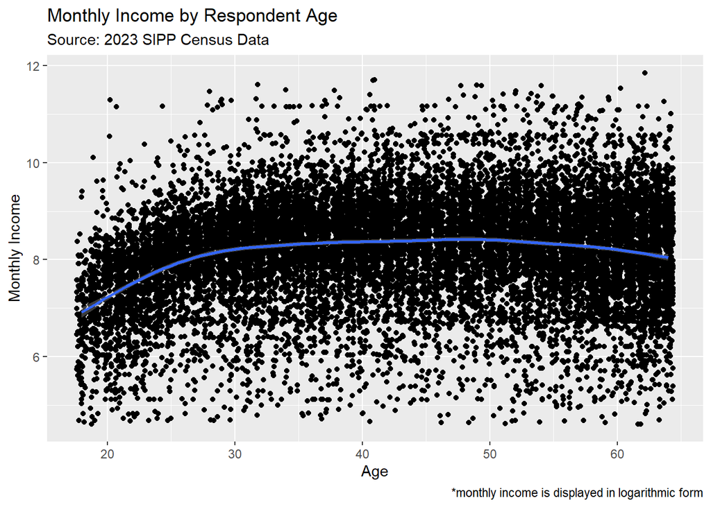

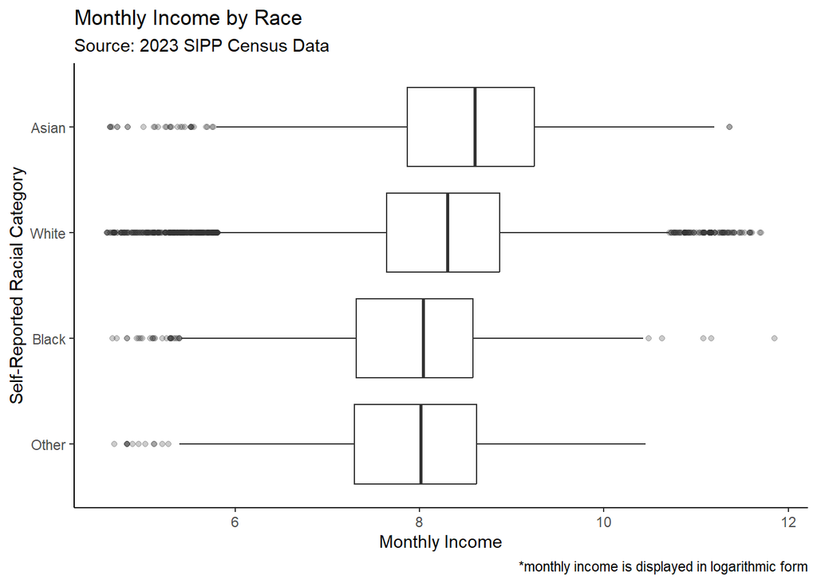

Grouping the survey responses into racial cohorts provides interesting insights as well. Visually we can see that the Asian group has the largest median monthly income with the White cohort in second. The Black and Other cohorts show similar characteristics and are relatively the same, tied for third in this basic comparison. There is another variable within the SIPP dataset that I could have pulled that expanded upon the “Other” category. However, I deemed this variable quality enough for the scope of this project. If further analysis were to be conducted I would go back and restructure the data to include the more detailed racial categories. For now this will suffice. Overall, I expect that the race demographic variable will have a significant impact on the model as a control.

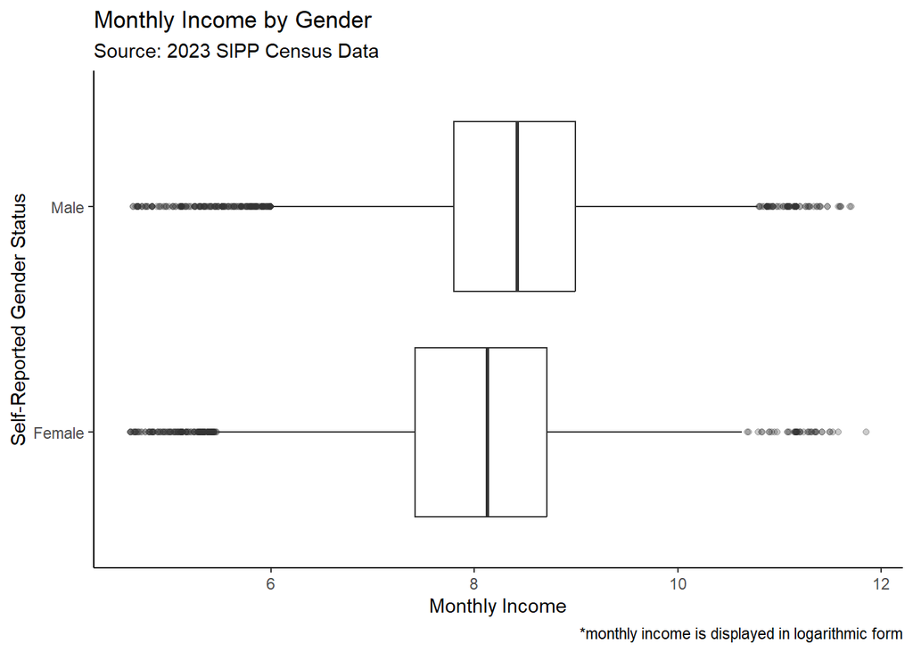

As expected, the median monthly income, when comparing across gender groups displays the commonly known economic characteristic that males in the workforce earn more income than females. There is an enormous amount of literature and research that attempts to explain this phenomenon and propose ideas to counteract it. I won’t go into too much more detail regarding this covariate. For our purposes, we are merely looking to see if the dataset we have created accurately reflects current reality (or the one that existed at the time of the interviews). What we see here in the data we can confirm with other outside sources of information. I expect this variable to have a significant impact on the model as well. It may even have an impact on the explanatory variable of interest (educational attainment) and further treatment would be needed to control for the potential co-linearity or other endogenous effects that gender might have on educational outcomes.

## Survey Design and Regression Analysis

SIPP survey data organization is structured into panels, waves, and reference periods. A SIPP panel is a group of households selected to be interviewed periodically over multiple years. These panels may run concurrently with others or alone. Waves created within each panel and are defined as a full cycle of administering the survey questions. From 2014 and on, each SIPP panel consist of 4 waves. Most SIPP questions asked during the interview referred to the preceding calendar year, this is the “reference period”. So for the 2023 SIPP survey, the questions asked referred to January to December 2022.

The SIPP sampling design is complex and goes above simple random sampling to determine which households are selected for an interview (see stratified sampling for further details). Because of this complex design, there are important guidelines needed when using SIPP data to properly account for standard error estimation. Because of the nature of the survey design, unless properly accounted for, the standard errors generated from typical modeling or other statistical analysis will underestimate the true standard errors of estimates from SIPP data.

```r
sipp_design <- svrepdesign(
  data = Final_Data_SIPP_2023,
  type = "Fay",
  repweights = "REPWGT[0-9]+",
  weights = ~WPFINWGT,
  combined.weights = TRUE,
  rho = 0.5,
  mse = TRUE
)
```

To properly account for the standard errors generated from non random sampling, I followed guidelines from the Census and attached the proper 2023 replicate weights to the core data. These were combined via specific identifier variables provided by SIPP data documentation. I chose to implement Fay’s Method of Balanced Repeated Replication in my analysis as it follows previous government and academic research using complex panel data, it provides consistency in variance estimation. See (https://www.bls.gov/osmr/research-papers/2008/pdf/st080070.pdf) for further insight into the effectiveness of Fay’s method for standard errors. The main concern with this choice is the potential for variance underestimation for small sample sizes. Other methodologies (Taylor Series, Balanced Repeated Replication, Jackknife, etc) all contain their own drawbacks as well. Fay’s Method is seen as the easiest to compute and implement.

### First OLS Regression (mimicking the Mincer Equation)

```r
Weighted_OLS_model <- svyglm(log_monthly_income ~ `education_type_Above HS Diploma` + TAGE + I(TAGE^2),
                    design = sipp_design)
```

Our first model attempts to replicate the Mincer Equation as is, this will help test the foundation of our analysis and help us know if we are going in the right direction. Using age (variable name TAGE) as a substitute for work experience, we see above our monthly income variable modeled as a function of educational attainment (in this case a dummy response of yes or no for “above high school diploma education level), age, and age^2.

### Second OLS Regression (adding in other explanatory variables based on the graphs from earlier)

```r
Weighted_OLS_model2 <- svyglm(log_monthly_income ~ `education_type_Above HS Diploma` + TAGE + I(TAGE^2) + sex + race + hisp_origin + living_quarters + license_or_cert +  martial_status + living_quarters + empstatus,
                     design = sipp_design)
```

Our second model introduces a set of demographic and other control variables contained within the SIPP dataset, including race, gender, Hispanic origin, marital status, and employment status to name a few. Theoretically, the inclusion of these variables will help to reduce the error term and create homogeneity in the models residuals, among other positive impacts. Generally speaking, I chose a multi-variable linear regression model for a couple of reasons. Firstly, this is the beginning of my return into “academic” type research, specifically with the implementation of econometrics. It has been since early 2021 since my last academic research project and I needed something manageable enough to not get lost in the sauce of theory while also not venturing into causal claims just yet. The groundwork for that type of analysis is hopefully being laid here. One day I will be confident enough and have a solid background to dive into questions like that, but as of right now OLS is where I live. And this is no knock to OLS estimations, there is a reason it is still being taught today.

### Comparison of the Two Models

```
##
## Multiple OLS Regression Results Comparison Table
## ===================================================================================
##                                                   log_monthly_income
##                                     Mincer Equation | Mincer Equation with Controls
##                                            (1)                     (2)
## -----------------------------------------------------------------------------------
## Education Above HS Diploma              0.538***                0.392***
##                                      (0.501, 0.574)          (0.356, 0.427)
##
## Age                                     0.125***                0.078***
##                                      (0.116, 0.135)          (0.069, 0.087)
##
## Age²                                    -0.001***               -0.001***
##                                     (-0.001, -0.001)        (-0.001, -0.001)
##
## Male (ref:Female)                                               0.314***
##                                                              (0.280, 0.347)
##
## Black (ref:Asian)                                               -0.258***
##                                                             (-0.341, -0.176)
##
## Other Race (ref:Asian)                                          -0.232***
##                                                             (-0.341, -0.124)
##
## White (ref:Asian)                                               -0.127***
##                                                             (-0.201, -0.053)
##
## Hispanic Origin                                                 -0.152***
##                                                             (-0.193, -0.111)
##
## Living Quarters: House/Apt/Flat                                  0.404*
##                                                              (-0.030, 0.837)
##
## Living Quarters: Mobile Home/Other)                               0.173
##                                                              (-0.268, 0.613)
##
## Obtained Professional License/Cert.                             0.117***
##                                                              (0.081, 0.154)
##
```

[output cut: 10 more lines]

```
##                                                              (-0.060, 0.154)
##
## Unemployed (ref:Employed)                                       -1.314***
##                                                             (-1.368, -1.260)
##
## Intercept                               5.157***                5.820***
##                                      (4.966, 5.348)          (5.333, 6.308)
##
## Observations                             15,881                  15,501
## Log Likelihood                         -23,609.290             -20,747.390
## Akaike Inf. Crit.                      47,226.580              41,528.780
## -----------------------------------------------------------------------------------
## Notes:                              ***Significant at the 1 percent level.
##                                     **Significant at the 5 percent level.
##                                     *Significant at the 10 percent level.
```

Our first model (Mincer Eq) shows that the variables included (education beyond HS, age, and age²) and the intercept itself are statistically significant at the generally accepted level of 95% and even at the 99% confidence level. The confidence intervals (the set of values below each coefficient) for model 1 show that our estimated range of the beta parameter does not include 0, meaning that age and education have a significant and non zero impact on monthly education within this dataset.

Moving on to the Mincer + Controls model we find similar results for the same variables that are present in model 1. Education above HS Diploma and age are still statistically significant and the trends of each variable seem to be accurately captured within the model. The estimated confidence intervals tell a similar story, zero is outside the bounds of both education and age meaning we can reject the null hypothesis that the true beta parameter is 0. Moving to the other control variables, the racial demographic variables and the sex indicator variable were statistically significant at both the 95% and 99% level. Travelling down the list we find that Hispanic origin, obtaining a professional license/certification, select marriage indicators (married and never married), and the employment status variable are all statistically significant as well at the levels mentioned previously.

### Comparision of Both Model Coefficients

Coefficients for Educational Attainment (Above HS Diploma)

| Mincer Equation | Mincer Equation with Controls |
| --- | --- |
| 1.712 | 1.48 |

The table above neatly displays the explanatory variable of interest for this analysis. Before interpreting these values, it is important to note that since the model is log-linear in nature, exponentiating the coefficient is required to properly interpret the results of the model. For every 1 unit increase in education type (i.e going from a HS Diploma to some type of higher educational attainment), we see and increase in monthly income by 71.2% in the first Mincer model, while the Mincer + Controls Model found an increase of 48.0%. Notice how that works. The coefficients in the regression output are 0.538 (model 1) and 0.392 (model 2). After converting the values using some R code, we come up with our real world interpretation. Imagine that we are taking the hypothetical value for monthly income at the high school diploma level and then multiplying it by 1.71, aka, taking the current value and adding 71.1%. The difference between the two outputs is expected, as we add in more control variables to the model the size of each coefficient should reduce, as more of the excess noise is being captured by the model predictors and not the error term.

Coefficients for Other Explanatory Variables of Interest

| Male (ref:Female) | Black (ref:Asian) | Other (ref:Asian) | White (ref:Asian) | Obtained Professional License/Cert. |
| --- | --- | --- | --- | --- |
| 1.369 | 0.772 | 0.793 | 0.881 | 1.124 |

The table above shows other independent variables I found interesting and predicted would have a significant impact back in the EDA section. Before continuing, I should make note that unless a dummy/indicator is designated within the linear regression (for a categorical variable, non-ordinal), R will use the first category listed (A-Z or numerically if coded as a numbers) as the reference category and base the coefficients on the reference category. This should help contextualize the results of my analysis.

Starting with the sex variable, our model reports that males earn a wage that is 36.9% higher than the reference category of females in the dataset. This variable had a significant impact on the results of the model as well. More analysis may need to be done in order to fully flesh out the interconnectedness of gender, education, and income. The race variable had a significant effect on our models results as well and seems to accurately reflect real world conditions to boot. The Black cohort made 77.2% of the monthly income that the reference group did (Asian in this case), the Other category made 79.3% of the income compared to the reference group, and the White cohort made 88.1% compared to Asians.

The last variable of interest to me was the professional license or certification indicator variable. This is actually the variable that first sparked my interest in the project. I thought it could be useful for educational and other organizations that promote workforce development to know whether or not their work-based education programs made a noticeable impact on the participants income levels. The Mincer Equation in addition with other covariates (with organization or enterprise specific data) could be very effective for internal evaluation or external reporting. From my model, I found that those with a professional license or certification make 12.4% more monthly income than those without these additional education gains.

## Robustness Check and Model Specification

This section of my report will consist of a brief discussion on model specification and whether or not we appropriately measured the effects of education levels on income. The traditional method of evaluating model selection is through a robustness check of residuals and visualization of said residuals generated from linear regression. I will not deviate from a tried and true methodology. The results are as follows.

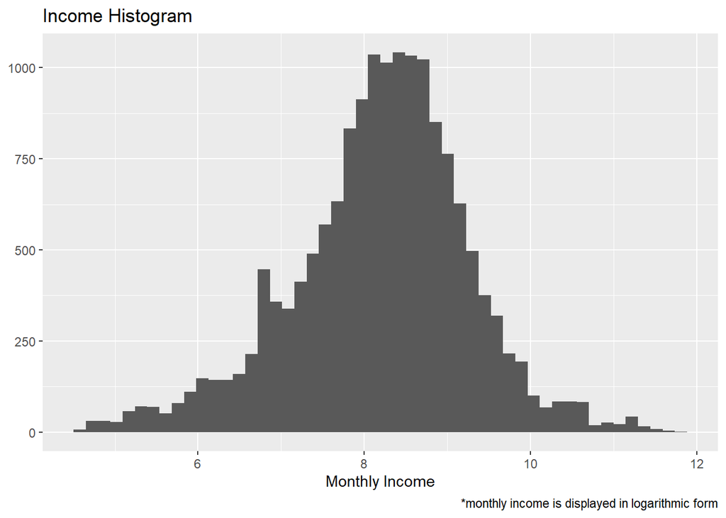

After some initial manipulation including filtering and logarithmic operations, the income variable is normally distributed, at least generally. There is no real world data that will follow an exactly normal distribution, so what we are seeing here will suffice and works for our general assumptions for linear modeling.

### Visualizing the Residuals for Both Models

#### Residuals vs Fitted Values Plots

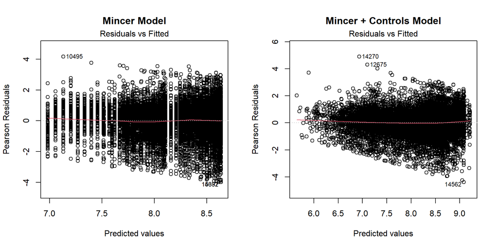

These two residuals vs. fitted plots help visualize any potential non-linear patterns within both models’ residuals. From my eye, there is no distinct pattern around the center line of 0, and the red line that follows the residual data shows only slight deviation above and below the defined pearson residual line. There may be some concerns with the distribution or density of the residuals however, to me there appear to be a large concentration of points between 7.5 and 8 and around 8.5 (in the first Mincer Model). While not as apparent, there appears to be a higher density of residuals as we travel right along the x axis for the Mincer + Controls plot as well. However overall, I would say our residuals vs fitted values plot passed linearity tests, reducing our concerns of a biased estimator.

#### Normal Q-Q Residuals Plots

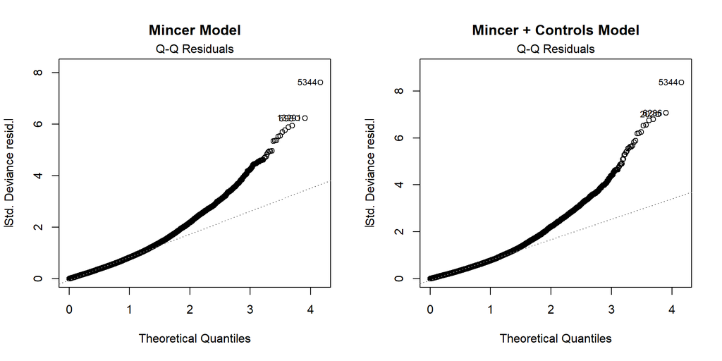

Education Levels Table

| education_type | n | percent |
| --- | --- | --- |
| Above HS Diploma | 10523 | 66.3% |
| High School Diploma/Equivalent | 4135 | 26.0% |
| Less than HS Diploma | 1223 | 7.7% |

#### Scale-Location Plots

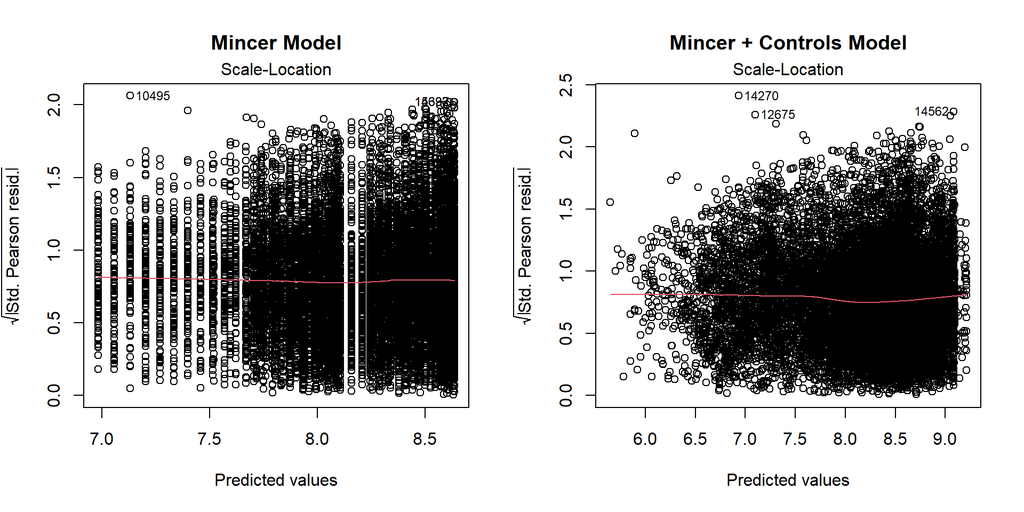

Our last robustness check will a test for homoscedasticity (constant variance of residuals). OLS regressions assume that the residuals generated by the model have equal variance and display no systemic patterns or changes (i.e their mean is 0). If there is heteroscedasticity our results would be very difficult to trust as there would be increased variance in our coefficients not properly captured by the model. Which could potentially lead to type 1 or type 2 errors in our hypothesis testing. In this instance, the residual variance appears to be generally constant. For both plots the red line is roughly horizontal across the plot. There are trends in both models that give cause for concern. It appears that in both models as we move right along the spread of the data points increases in a slight cone shape, with the smaller end of the cone on the left and larger end on the right. This is a problem that needs to be addressed before making real world policy decisions. A Breusch-Pagan Test where the null hypothesis states that residuals are homoscedastic and the alternative hypothesis is that the residuals are heteroscedastic (there is an uneven spread of residuals) would help solidify our findings.

## Conclusion

This project was an excellent test of my abilities using R as a programming language and getting my feet wet in the field of statistical research. I am sure that there are plenty of places where I could have been more efficient, better optimized, or even had better ideas. But that is not the point, the point was to get back on the horse of econometric modeling and research. I will say that I genuinely enjoyed the process and feel that I have expanded and reinforced my understanding of statistical concepts.

I have been teaching myself to use R since February 2025. I would call this project a success overall. I learned about linear regressions in R (having only a STATA background), greatly expanded my abilities to do EDA in R and visualize general trends with slick charts and graphs, and learned how to create markdown files and compile all of my results in a neatly organized document. The next step is getting this posted to Github (if you are reading this you know I have completed that step haha).

From here I can either dive deeper into this data and re test my hypothesis using a more granular education variable, or I can call this a wash and move on to a whole new project. I will probably end up doing both. In the mean time I need to brainstorm new projects to do in R.